# Analisis Hasil Survey Kepuasan Mahasiswa Layanan manajemen oleh UPPS

## Program Studi Administrasi Rumah Sakit

link data -> https://drive.google.com/file/d/1hdRaeklrpz045Zg1va-PKIHMWhIBwrRk/view?usp=sharing

### Uji Reabilitas Cronbach alpha >0.70

```python
print(f"Cronbach's alpha: {alpha}")
```

```
Cronbach's alpha: 0.9639407598197038
```

### Uji Validitas - Pearson correlation

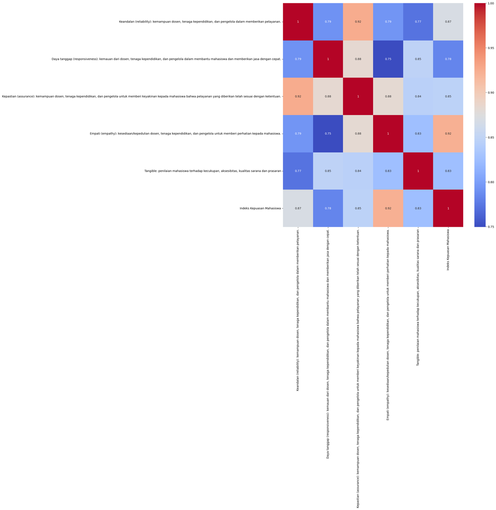

```python
plt.figure(figsize=(14, 14))
sns.heatmap(corr_matrix, annot=True, cmap='coolwarm')
plt.show()
```

```python
corr_matrix
#Matrik Korelasi
```

|  | Keandalan (reliability): kemampuan dosen, tenaga kependidikan, dan pengelola dalam memberikan pelayanan. | Daya tanggap (responsiveness): kemauan dari dosen, tenaga kependidikan, dan pengelola dalam membantu mahasiswa dan memberikan jasa dengan cepat. | Kepastian (assurance): kemampuan dosen, tenaga kependidikan, dan pengelola untuk memberi keyakinan kepada mahasiswa bahwa pelayanan yang diberikan telah sesuai dengan ketentuan. | Empati (empathy): kesediaan/kepedulian dosen, tenaga kependidikan, dan pengelola untuk memberi perhatian kepada mahasiswa. | Tangible: penilaian mahasiswa terhadap kecukupan, aksesibitas, kualitas sarana dan prasaran | Indeks Kepuasan Mahasiswa |
| --- | --- | --- | --- | --- | --- | --- |
| Keandalan (reliability): kemampuan dosen, tenaga kependidikan, dan pengelola dalam memberikan pelayanan. | 1.000000 | 0.790613 | 0.924800 | 0.793317 | 0.772315 | 0.869483 |
| Daya tanggap (responsiveness): kemauan dari dosen, tenaga kependidikan, dan pengelola dalam membantu mahasiswa dan memberikan jasa dengan cepat. | 0.790613 | 1.000000 | 0.883510 | 0.749511 | 0.848059 | 0.783389 |
| Kepastian (assurance): kemampuan dosen, tenaga kependidikan, dan pengelola untuk memberi keyakinan kepada mahasiswa bahwa pelayanan yang diberikan telah sesuai dengan ketentuan. | 0.924800 | 0.883510 | 1.000000 | 0.882328 | 0.844643 | 0.847229 |
| Empati (empathy): kesediaan/kepedulian dosen, tenaga kependidikan, dan pengelola untuk memberi perhatian kepada mahasiswa. | 0.793317 | 0.749511 | 0.882328 | 1.000000 | 0.825504 | 0.922540 |
| Tangible: penilaian mahasiswa terhadap kecukupan, aksesibitas, kualitas sarana dan prasaran | 0.772315 | 0.848059 | 0.844643 | 0.825504 | 1.000000 | 0.825045 |
| Indeks Kepuasan Mahasiswa | 0.869483 | 0.783389 | 0.847229 | 0.922540 | 0.825045 | 1.000000 |

### Analisis

Berdasarkan matriks korelasi diatas yang menunjukkan hubungan antara berbagai aspek kepuasan mahasiswa dan Indeks Kepuasan Mahasiswa secara keseluruhan. Nilai dalam matriks berkisar dari 0 hingga 1, di mana nilai yang lebih tinggi menunjukkan korelasi yang lebih kuat antara dua variabel.

Berikut adalah beberapa analisis dari matriks korelasi diatas:

1. Keandalan (Reliability) memiliki korelasi yang kuat dengan Indeks Kepuasan Mahasiswa (0.869), menunjukkan bahwa kemampuan dosen, tenaga kependidikan, dan pengelola dalam memberikan pelayanan sangat penting bagi kepuasan mahasiswa.
2. Empati (Empathy) juga menunjukkan korelasi yang sangat kuat dengan Indeks Kepuasan Mahasiswa (0.923), yang berarti kesediaan dan kepedulian dosen, tenaga kependidikan, dan pengelola dalam memberikan perhatian kepada mahasiswa sangat berpengaruh terhadap kepuasan mereka.
3. Daya Tanggap (Responsiveness) memiliki korelasi yang lebih rendah dengan Indeks Kepuasan Mahasiswa (0.783) dibandingkan dengan Keandalan dan Empati, namun masih menunjukkan hubungan yang signifikan.
4. Kepastian (Assurance) dan Tangible (yang berkaitan dengan sarana dan prasarana) memiliki korelasi yang hampir sama dengan Indeks Kepuasan Mahasiswa, yaitu 0.847 dan 0.825, menunjukkan bahwa kedua aspek ini juga penting tetapi mungkin tidak sekuat Keandalan atau Empati.
5. Korelasi antara variabel-variabel itu sendiri (misalnya, antara Keandalan dan Daya Tanggap) juga cukup tinggi, menunjukkan bahwa aspek-aspek kepuasan ini sering kali berjalan bersamaan.

Dari analisis diatas, dapat disimpulkan bahwa untuk meningkatkan Indeks Kepuasan Mahasiswa secara keseluruhan, fokus utama harus diberikan pada peningkatan Keandalan dan Empati, diikuti oleh Kepastian, Tangible, dan Daya Tanggap. Ini bisa menjadi masukan bagi Fakultas Sains Teknologi dan Kesehatan dan Program Studi Administrasi rumah sakit untuk memprioritaskan area-area tertentu dalam upaya peningkatan kualitas layanan mereka.

### Temuan

Ada beberapa temuan menarik yang dapat membantu meningkatkan pelayanan Fakultas atau program studi:

1. Empati (Empathy) memiliki korelasi tertinggi dengan Indeks Kepuasan Mahasiswa. Ini menunjukkan bahwa perhatian pribadi dan kepedulian yang diberikan oleh dosen dan staf kepada mahasiswa sangat penting. Fakultas dapat meningkatkan pelatihan untuk staf dalam hal komunikasi dan interaksi dengan mahasiswa untuk memastikan bahwa mereka merasa didengar dan dihargai.
2. Keandalan (Reliability) juga memiliki korelasi yang sangat tinggi dengan kepuasan mahasiswa. Ini berarti bahwa mahasiswa menghargai konsistensi dan keandalan dalam layanan yang mereka terima. Fakultas dapat bekerja untuk memastikan bahwa jadwal, prosedur, dan kebijakan diterapkan secara konsisten dan dapat diandalkan.
3. Tangible, atau penilaian terhadap sarana dan prasarana, meskipun memiliki korelasi yang lebih rendah dibandingkan dengan Empati dan Keandalan, tetap penting. Investasi dalam perbaikan fasilitas fisik dan aksesibilitas dapat membantu meningkatkan persepsi mahasiswa terhadap kualitas pendidikan yang mereka terima.
4. Daya Tanggap (Responsiveness) dan Kepastian (Assurance) memiliki korelasi yang signifikan tetapi lebih rendah dibandingkan dengan Empati dan Keandalan. Ini menunjukkan bahwa sementara mahasiswa menghargai respons cepat dan kepastian dalam layanan, faktor-faktor ini mungkin tidak seberat Empati dan Keandalan. Namun, peningkatan di area ini masih akan berkontribusi pada peningkatan kepuasan mahasiswa. Dengan fokus pada peningkatan Empati dan Keandalan serta memperhatikan aspek Tangible, Responsiveness, dan Assurance, Fakultas atau program studi dapat menciptakan pengalaman yang lebih memuaskan bagi mahasiswa.

### Analisis Regresi

```python
model.summary()
```

OLS Regression Results

| Dep. Variable: | Q('Indeks Kepuasan Mahasiswa') | R-squared: | 0.963 |
| --- | --- | --- | --- |
| Model: | OLS | Adj. R-squared: | 0.950 |
| Method: | Least Squares | F-statistic: | 77.12 |
| Date: | Sat, 09 Mar 2024 | Prob (F-statistic): | 3.69e-10 |
| Time: | 21:35:49 | Log-Likelihood: | 16.742 |
| No. Observations: | 21 | AIC: | -21.48 |
| Df Residuals: | 15 | BIC: | -15.22 |
| Df Model: | 5 |  |  |
| Covariance Type: | nonrobust |  |  |

|  | coef | std err | t | P>\|t\| | [0.025 | 0.975] |
| --- | --- | --- | --- | --- | --- | --- |
| Intercept | 0.0421 | 0.254 | 0.166 | 0.871 | -0.500 | 0.584 |
| Q('Keandalan (reliability): kemampuan dosen, tenaga kependidikan, dan pengelola dalam memberikan pelayanan.') | 0.7795 | 0.130 | 5.983 | 0.000 | 0.502 | 1.057 |
| Q('Daya tanggap (responsiveness): kemauan dari dosen, tenaga kependidikan, dan pengelola dalam membantu mahasiswa dan memberikan jasa dengan cepat.') | 0.3660 | 0.122 | 2.992 | 0.009 | 0.105 | 0.627 |
| Q('Kepastian (assurance): kemampuan dosen, tenaga kependidikan, dan pengelola untuk memberi keyakinan kepada mahasiswa bahwa pelayanan yang diberikan telah sesuai dengan ketentuan.') | -0.8109 | 0.167 | -4.851 | 0.000 | -1.167 | -0.455 |
| Q('Empati (empathy): kesediaan/kepedulian dosen, tenaga kependidikan, dan pengelola untuk memberi perhatian kepada mahasiswa.') | 0.6508 | 0.085 | 7.677 | 0.000 | 0.470 | 0.832 |
| Q('Tangible: penilaian mahasiswa terhadap kecukupan, aksesibitas, kualitas sarana dan prasaran') | 0.0123 | 0.081 | 0.152 | 0.881 | -0.160 | 0.184 |

| Omnibus: | 15.628 | Durbin-Watson: | 2.033 |
| --- | --- | --- | --- |
| Prob(Omnibus): | 0.000 | Jarque-Bera (JB): | 14.865 |
| Skew: | 1.680 | Prob(JB): | 0.000592 |
| Kurtosis: | 5.388 | Cond. No. | 88.6 |

Notes:  
[1] Standard Errors assume that the covariance matrix of the errors is correctly specified.

Berdasarkan hasil regresi diatas, berikut adalah analisisnya:

- Intercept: Nilai koefisien sangat rendah dan tidak signifikan secara statistik (p-value 0.871), yang menunjukkan bahwa tanpa mempertimbangkan variabel lain, nilai dasar untuk variabel dependen sangat kecil dan tidak memiliki pengaruh yang signifikan.
- Keandalan (Reliability): Koefisien positif yang tinggi (0.7795) dan signifikan secara statistik (p-value 0.000), menunjukkan bahwa keandalan dosen, tenaga kependidikan, dan pengelola memiliki pengaruh yang kuat dan positif terhadap variabel dependen.
- Daya Tanggap (Responsiveness): Koefisien positif (0.3660) dengan signifikansi statistik (p-value 0.009), menunjukkan bahwa daya tanggap juga berkontribusi positif terhadap variabel dependen, tetapi tidak sekuat keandalan.
- Kepastian (Assurance): Koefisien negatif yang besar (-0.8109) dan signifikan secara statistik (p-value 0.000), menunjukkan bahwa ada hubungan negatif antara kepastian dan variabel dependen. Ini bisa berarti bahwa ada aspek dari kepastian yang tidak sesuai dengan ekspektasi mahasiswa atau ada faktor lain yang mempengaruhi hubungan ini.
- Empati (Empathy): Koefisien positif yang tinggi (0.6508) dan signifikan secara statistik (p-value 0.000), menunjukkan bahwa empati memiliki pengaruh yang sangat kuat dan positif terhadap variabel dependen, hampir sebanding dengan keandalan.
- Tangible: Koefisien sangat rendah (0.0123) dan tidak signifikan secara statistik (p-value 0.881), menunjukkan bahwa penilaian mahasiswa terhadap sarana dan prasarana tidak memiliki pengaruh yang signifikan terhadap variabel dependen dalam model ini.

Dari analisis diatas, dapat disimpulkan bahwa keandalan dan empati adalah faktor yang paling penting dalam meningkatkan variabel dependen, sementara kepastian memiliki efek negatif yang perlu diteliti lebih lanjut. Sarana dan prasarana (Tangible) tampaknya tidak memiliki pengaruh yang signifikan dalam model ini.

### Diagram

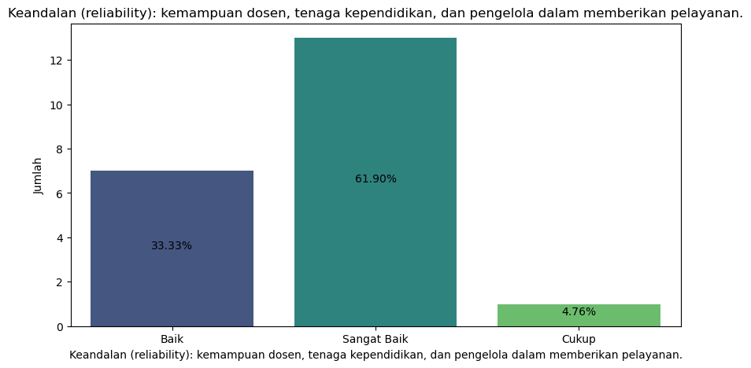

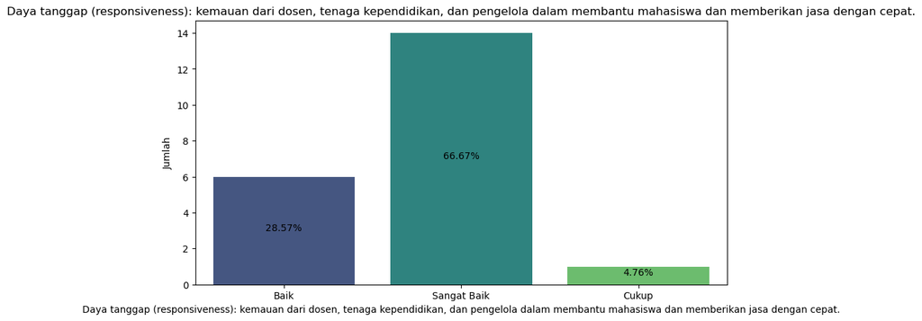

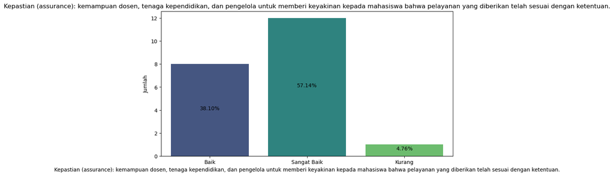

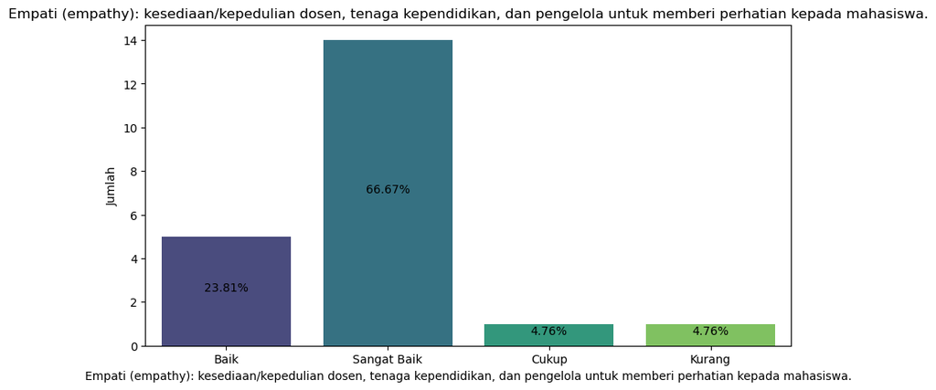

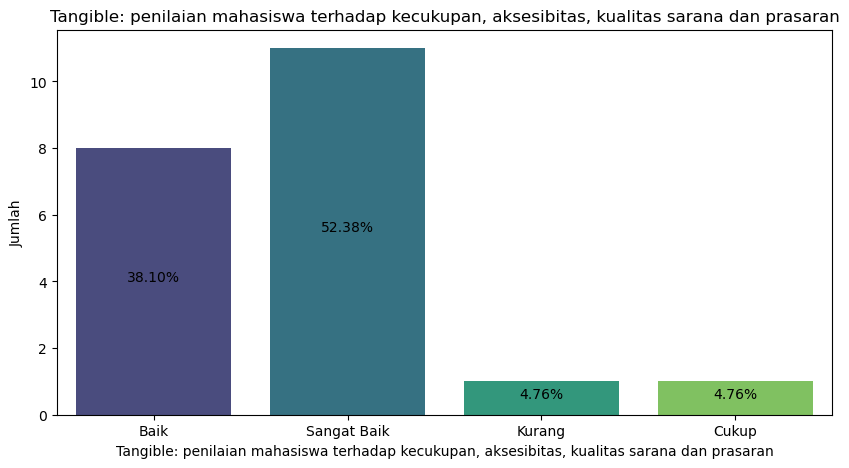

```python
import pandas as pd
import matplotlib.pyplot as plt
import seaborn as sns

# Baca data Anda dari file CSV
# df = pd.read_csv('Dosen-ARS- Visi Misi Prodi ARS.csv', delimiter=';')

# Buat diagram balok untuk setiap kolom
for column in data_diagram.columns:
    plt.figure(figsize=(10, 5))
    ax = sns.countplot(x=column, data=df, palette='viridis')
    plt.title(column)
    plt.ylabel('Jumlah')

    # Tampilkan persentase di dalam setiap balok
    total = len(df[column])
    for p in ax.patches:
        height = p.get_height()
        ax.text(p.get_x()+p.get_width()/2.,
                height/2,
                '{:1.2f}%'.format(height/total*100),
                ha="center")
    plt.show()
```

```python
def konversi_kepuasan(nilai):
    if nilai <= 1:
        return 'Sangat Kurang Memuaskan'
    elif nilai <= 2:
        return 'Kurang Memuaskan'
    elif nilai <= 3:
        return 'Cukup Memuaskan'
    elif nilai <= 4:
        return 'Memuaskan'
    else:
        return 'Sangat Memuaskan'

def konversi_kepuasan_baik(nilai):
    if nilai <= 1:
        return 'Kurang'
    elif nilai <= 2:
        return 'Cukup'
    elif nilai <= 3:
        return 'Baik'
    else:
        return 'Sangat Baik'
```

```python
sheet_name = "Layanan manajemen oleh UPPS"
prodi = 'Administrasi Rumah Sakit'
import pandas as pd
data = pd.read_excel('Kuesioner Mahasiswa - Fakultas Sains Teknologi dan Kesehatan (Jawaban) (1).xlsx', sheet_name=sheet_name)
data_filtered = data[data['Program Studi'] == prodi]
# print(data_filtered)
data_filtered = data_filtered.drop('Program Studi', axis=1)
data_diagram = data_filtered.copy()
# data_filtered.to_csv("mahasiswa-"+sheet_name+'.csv', index=False)
df = data_filtered
dfx = data_filtered.copy()

mapping={'Cukup Memuaskan':3,'Sangat Kurang Memuaskan':1,
 'Kurang Memuaskan':2, 'Memuaskan':4, 'Sangat memuaskan':5, 'Ya':5, 'Tidak':1, 'Belum tahu':3,'Sangat Memuaskan':5,
    'Sangat Baik': 4,
    'Baik': 3,
    'Cukup': 2,
    'Kurang': 1
        }
for col in dfx.columns:
    dfx[col] = dfx[col].map(mapping)

df['Indeks Kepuasan Mahasiswa'] = dfx[dfx.columns.tolist()].mean(axis=1).apply(konversi_kepuasan_baik)
df.to_csv("mahasiswa-"+sheet_name+'.csv', index=False)
```

```python
# df
```

```python
# data_filtered
```

# Uji Validasi Pearson

```python
# nama_file = "Penelitian"
```

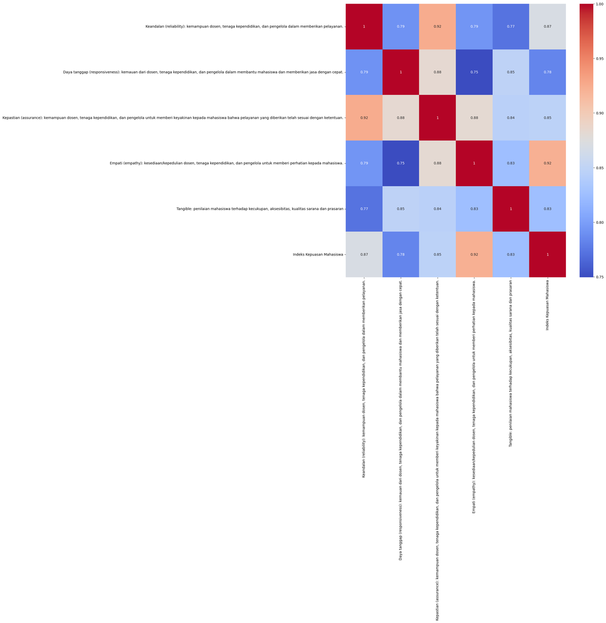

```python
import pandas as pd
import seaborn as sns
import matplotlib.pyplot as plt

# Ganti 'namafile.csv' dengan nama file Anda
# df = pd.read_csv(nama_file+'.csv', delimiter=';')

# Ubah data menjadi numerik
# mapping = {
#     'Kurang Puas': 1,
#     'Cukup Puas': 2,
#     'Puas': 3,
#     'Sangat Puas': 4
# }

# mapping={'Cukup Memuaskan':3,'Sangat Kurang Memuaskan':1,
#  'Kurang Memuaskan':2, 'Memuaskan':4, 'Sangat memuaskan':5, 'Ya':5, 'Tidak':1, 'Belum tahu':3}
for col in df.columns:
    df[col] = df[col].map(mapping)

# Hitung matriks korelasi
corr_matrix = df.corr()

# Cetak matriks korelasi
# print(corr_matrix)

# Plot heatmap dari matriks korelasi
plt.figure(figsize=(14, 14))
sns.heatmap(corr_matrix, annot=True, cmap='coolwarm')
plt.show()
```

```python
# df_t = df
# # df_t['indeks_kepuasan_mahasiswa'] = df_t[['skor1', 'skor2', 'skor3']].mean(axis=1)
# df.columns.tolist()
# df_t[df.columns.tolist()].mean(axis=1)
```

# Uji Reabilitas Cronbach alpha >0.70

```python
import pandas as pd
from scipy.stats import pearsonr

# Ganti 'namafile.csv' dengan nama file Anda
# df = pd.read_csv(nama_file+'.csv', delimiter=';')

# Ubah data menjadi numerik
# mapping = {
#     'Kurang Puas': 1,
#     'Cukup Puas': 2,
#     'Puas': 3,
#     'Sangat Puas': 4
# # }
# for col in df.columns:
#     df[col] = df[col].map(mapping)

def cronbach_alpha(df):
    # Hitung jumlah item dan varians item
    item_count = df.shape[1]
    item_variance = df.var(axis=0, ddof=1)

    # Hitung varians total skor
    total_scores = df.sum(axis=1)
    total_variance = total_scores.var(ddof=1)

    # Hitung Cronbach's alpha
    alpha = (item_count / (item_count - 1)) * (1 - (item_variance.sum() / total_variance))

    return alpha

# Hitung Cronbach's alpha
alpha = cronbach_alpha(df)
print(f"Cronbach's alpha: {alpha}")
```

```
Cronbach's alpha: 0.9639407598197038
```

```python
df
```

|  | Keandalan (reliability): kemampuan dosen, tenaga kependidikan, dan pengelola dalam memberikan pelayanan. | Daya tanggap (responsiveness): kemauan dari dosen, tenaga kependidikan, dan pengelola dalam membantu mahasiswa dan memberikan jasa dengan cepat. | Kepastian (assurance): kemampuan dosen, tenaga kependidikan, dan pengelola untuk memberi keyakinan kepada mahasiswa bahwa pelayanan yang diberikan telah sesuai dengan ketentuan. | Empati (empathy): kesediaan/kepedulian dosen, tenaga kependidikan, dan pengelola untuk memberi perhatian kepada mahasiswa. | Tangible: penilaian mahasiswa terhadap kecukupan, aksesibitas, kualitas sarana dan prasaran | Indeks Kepuasan Mahasiswa |
| --- | --- | --- | --- | --- | --- | --- |
| 0 | 3 | 3 | 3 | 3 | 3 | 3 |
| 2 | 4 | 4 | 4 | 4 | 3 | 4 |
| 3 | 4 | 4 | 4 | 4 | 4 | 4 |
| 4 | 3 | 3 | 3 | 4 | 3 | 4 |
| 5 | 4 | 4 | 4 | 4 | 4 | 4 |
| 8 | 4 | 4 | 4 | 4 | 3 | 4 |
| 9 | 4 | 4 | 4 | 4 | 4 | 4 |
| 10 | 3 | 4 | 3 | 4 | 4 | 4 |
| 11 | 4 | 4 | 4 | 4 | 4 | 4 |
| 13 | 4 | 4 | 4 | 4 | 4 | 4 |
| 15 | 4 | 3 | 3 | 3 | 3 | 4 |
| 16 | 3 | 4 | 3 | 2 | 3 | 3 |
| 17 | 2 | 2 | 1 | 1 | 1 | 2 |
| 22 | 4 | 4 | 4 | 4 | 4 | 4 |
| 23 | 3 | 3 | 3 | 3 | 3 | 3 |
| 25 | 3 | 3 | 3 | 3 | 3 | 3 |
| 26 | 4 | 4 | 4 | 4 | 4 | 4 |
| 27 | 3 | 3 | 3 | 3 | 2 | 3 |
| 32 | 4 | 4 | 4 | 4 | 4 | 4 |
| 38 | 4 | 4 | 4 | 4 | 4 | 4 |
| 39 | 4 | 4 | 4 | 4 | 4 | 4 |

# Korelasi

```python
import pandas as pd
import numpy as np

# Misalkan Anda memiliki DataFrame pandas 'df' dengan data Anda
# df = pd.read_csv(nama_file+'.csv', delimiter=';')  # Ganti 'data.csv' dengan path file CSV Anda

# Mengubah data kategorikal menjadi numerik
# df = df.replace({'Kurang Puang': 1, 'Cukup Puas':2, 'Puas': 3, 'Sangat Puas':4})

# Menghitung korelasi antara variabel
correlation_matrix = df.corr()

# Membulatkan hasil korelasi menjadi tiga angka di belakang koma
correlation_matrix = correlation_matrix.round(3)

# Menampilkan matriks korelasi dalam bentuk tabel
print(correlation_matrix)

# Mengekspor matriks korelasi ke file CSV
correlation_matrix.to_excel('Mahasiswa-'+sheet_name+"-correlation_matrix.xlsx")
correlation_matrix.to_csv('Mahasiswa-'+sheet_name+"-correlation_matrix.csv")
```

```
                                                    Keandalan (reliability): kemampuan dosen, tenaga kependidikan, dan pengelola dalam memberikan pelayanan.  \
Keandalan (reliability): kemampuan dosen, tenag...                                              1.000
Daya tanggap (responsiveness): kemauan dari dos...                                              0.791
Kepastian (assurance): kemampuan dosen, tenaga ...                                              0.925
Empati (empathy): kesediaan/kepedulian dosen, t...                                              0.793
Tangible: penilaian mahasiswa terhadap kecukupa...                                              0.772
Indeks Kepuasan Mahasiswa                                                                       0.869

                                                    Daya tanggap (responsiveness): kemauan dari dosen, tenaga kependidikan, dan pengelola dalam membantu mahasiswa dan memberikan jasa dengan cepat.  \
Keandalan (reliability): kemampuan dosen, tenag...                                              0.791
Daya tanggap (responsiveness): kemauan dari dos...                                              1.000
Kepastian (assurance): kemampuan dosen, tenaga ...                                              0.884
Empati (empathy): kesediaan/kepedulian dosen, t...                                              0.750
Tangible: penilaian mahasiswa terhadap kecukupa...                                              0.848
Indeks Kepuasan Mahasiswa                                                                       0.783

                                                    Kepastian (assurance): kemampuan dosen, tenaga kependidikan, dan pengelola untuk memberi keyakinan kepada mahasiswa bahwa pelayanan yang diberikan telah sesuai dengan ketentuan.  \
Keandalan (reliability): kemampuan dosen, tenag...                                              0.925
Daya tanggap (responsiveness): kemauan dari dos...                                              0.884
Kepastian (assurance): kemampuan dosen, tenaga ...                                              1.000
Empati (empathy): kesediaan/kepedulian dosen, t...                                              0.882
Tangible: penilaian mahasiswa terhadap kecukupa...                                              0.845
Indeks Kepuasan Mahasiswa                                                                       0.847

                                                    Empati (empathy): kesediaan/kepedulian dosen, tenaga kependidikan, dan pengelola untuk memberi perhatian kepada mahasiswa.  \
Keandalan (reliability): kemampuan dosen, tenag...                                              0.793
Daya tanggap (responsiveness): kemauan dari dos...                                              0.750
Kepastian (assurance): kemampuan dosen, tenaga ...                                              0.882
Empati (empathy): kesediaan/kepedulian dosen, t...                                              1.000
Tangible: penilaian mahasiswa terhadap kecukupa...                                              0.826
Indeks Kepuasan Mahasiswa                                                                       0.923

                                                    Tangible: penilaian mahasiswa terhadap kecukupan, aksesibitas, kualitas sarana dan prasaran  \
Keandalan (reliability): kemampuan dosen, tenag...                                              0.772
Daya tanggap (responsiveness): kemauan dari dos...                                              0.848
Kepastian (assurance): kemampuan dosen, tenaga ...                                              0.845
Empati (empathy): kesediaan/kepedulian dosen, t...                                              0.826
Tangible: penilaian mahasiswa terhadap kecukupa...                                              1.000
Indeks Kepuasan Mahasiswa                                                                       0.825

                                                    Indeks Kepuasan Mahasiswa
Keandalan (reliability): kemampuan dosen, tenag...                      0.869
Daya tanggap (responsiveness): kemauan dari dos...                      0.783
Kepastian (assurance): kemampuan dosen, tenaga ...                      0.847
Empati (empathy): kesediaan/kepedulian dosen, t...                      0.923
Tangible: penilaian mahasiswa terhadap kecukupa...                      0.825
Indeks Kepuasan Mahasiswa                                               1.000
```

# Regresi Linier

```python
import pandas as pd
import statsmodels.api as sm
from statsmodels.formula.api import ols

# Baca data Anda dari file CSV
# df = pd.read_csv('mahasiswa-Sarpras dan Keuangan.csv', delimiter=',')

# Ubah data ordinal menjadi data numerik
# ordinal_mapping = {
#     'Kurang Puas': 1,
#     'Cukup Puas': 2,
#     'Puas': 3,
#     'Sangat Puas': 4
# }
# for column in df.columns:
#     df[column] = df[column].map(mapping)

# Buat string formula untuk semua variabel X
predictors = df.columns.drop('Indeks Kepuasan Mahasiswa')
formula = 'Q(\'Indeks Kepuasan Mahasiswa\') ~ ' + ' + '.join(f'Q(\'{col}\')' for col in predictors)

# Lakukan analisis regresi ordinal dengan semua variabel X
model = ols(formula, data=df).fit()

# Cetak hasil
print(model.summary())

results_df = pd.DataFrame(model.summary().tables[1])

# Ekspor DataFrame ke file CSV
results_df.to_csv('Mahasiswa-'+sheet_name+'-summary.csv', index=False)
```

```
                                  OLS Regression Results
==========================================================================================
Dep. Variable:     Q('Indeks Kepuasan Mahasiswa')   R-squared:                       0.963
Model:                                        OLS   Adj. R-squared:                  0.950
Method:                             Least Squares   F-statistic:                     77.12
Date:                            Sat, 09 Mar 2024   Prob (F-statistic):           3.69e-10
Time:                                    21:05:56   Log-Likelihood:                 16.742
No. Observations:                              21   AIC:                            -21.48
Df Residuals:                                  15   BIC:                            -15.22
Df Model:                                       5
Covariance Type:                        nonrobust
==========================================================================================================================================================================================================================================================
                                                                                                                                                                                             coef    std err          t      P>|t|      [0.025      0.975]
----------------------------------------------------------------------------------------------------------------------------------------------------------------------------------------------------------------------------------------------------------
Intercept                                                                                                                                                                                  0.0421      0.254      0.166      0.871      -0.500       0.584
Q('Keandalan (reliability): kemampuan dosen, tenaga kependidikan, dan pengelola dalam memberikan pelayanan.')                                                                              0.7795      0.130      5.983      0.000       0.502       1.057
Q('Daya tanggap (responsiveness): kemauan dari dosen, tenaga kependidikan, dan pengelola dalam membantu mahasiswa dan memberikan jasa dengan cepat.')                                      0.3660      0.122      2.992      0.009       0.105       0.627
Q('Kepastian (assurance): kemampuan dosen, tenaga kependidikan, dan pengelola untuk memberi keyakinan kepada mahasiswa bahwa pelayanan yang diberikan telah sesuai dengan ketentuan.')    -0.8109      0.167     -4.851      0.000      -1.167      -0.455
Q('Empati (empathy): kesediaan/kepedulian dosen, tenaga kependidikan, dan pengelola untuk memberi perhatian kepada mahasiswa.')                                                            0.6508      0.085      7.677      0.000       0.470       0.832
Q('Tangible: penilaian mahasiswa terhadap kecukupan, aksesibitas, kualitas sarana dan prasaran')                                                                                           0.0123      0.081      0.152      0.881      -0.160       0.184
==============================================================================
Omnibus:                       15.628   Durbin-Watson:                   2.033
Prob(Omnibus):                  0.000   Jarque-Bera (JB):               14.865
Skew:                           1.680   Prob(JB):                     0.000592
Kurtosis:                       5.388   Cond. No.                         88.6
==============================================================================

Notes:
[1] Standard Errors assume that the covariance matrix of the errors is correctly specified.
```

```python
df
```

|  | Keandalan (reliability): kemampuan dosen, tenaga kependidikan, dan pengelola dalam memberikan pelayanan. | Daya tanggap (responsiveness): kemauan dari dosen, tenaga kependidikan, dan pengelola dalam membantu mahasiswa dan memberikan jasa dengan cepat. | Kepastian (assurance): kemampuan dosen, tenaga kependidikan, dan pengelola untuk memberi keyakinan kepada mahasiswa bahwa pelayanan yang diberikan telah sesuai dengan ketentuan. | Empati (empathy): kesediaan/kepedulian dosen, tenaga kependidikan, dan pengelola untuk memberi perhatian kepada mahasiswa. | Tangible: penilaian mahasiswa terhadap kecukupan, aksesibitas, kualitas sarana dan prasaran | Indeks Kepuasan Mahasiswa |
| --- | --- | --- | --- | --- | --- | --- |
| 0 | 3 | 3 | 3 | 3 | 3 | 3 |
| 2 | 4 | 4 | 4 | 4 | 3 | 4 |
| 3 | 4 | 4 | 4 | 4 | 4 | 4 |
| 4 | 3 | 3 | 3 | 4 | 3 | 4 |
| 5 | 4 | 4 | 4 | 4 | 4 | 4 |
| 8 | 4 | 4 | 4 | 4 | 3 | 4 |
| 9 | 4 | 4 | 4 | 4 | 4 | 4 |
| 10 | 3 | 4 | 3 | 4 | 4 | 4 |
| 11 | 4 | 4 | 4 | 4 | 4 | 4 |
| 13 | 4 | 4 | 4 | 4 | 4 | 4 |
| 15 | 4 | 3 | 3 | 3 | 3 | 4 |
| 16 | 3 | 4 | 3 | 2 | 3 | 3 |
| 17 | 2 | 2 | 1 | 1 | 1 | 2 |
| 22 | 4 | 4 | 4 | 4 | 4 | 4 |
| 23 | 3 | 3 | 3 | 3 | 3 | 3 |
| 25 | 3 | 3 | 3 | 3 | 3 | 3 |
| 26 | 4 | 4 | 4 | 4 | 4 | 4 |
| 27 | 3 | 3 | 3 | 3 | 2 | 3 |
| 32 | 4 | 4 | 4 | 4 | 4 | 4 |
| 38 | 4 | 4 | 4 | 4 | 4 | 4 |
| 39 | 4 | 4 | 4 | 4 | 4 | 4 |

```python
df.to_csv('cek nana-'+sheet_name+'-summary.csv', index=False)
```

```python
#
```

```python
# print(df)
```